# R for Non-R Users

We can change the axis labels and add a title:

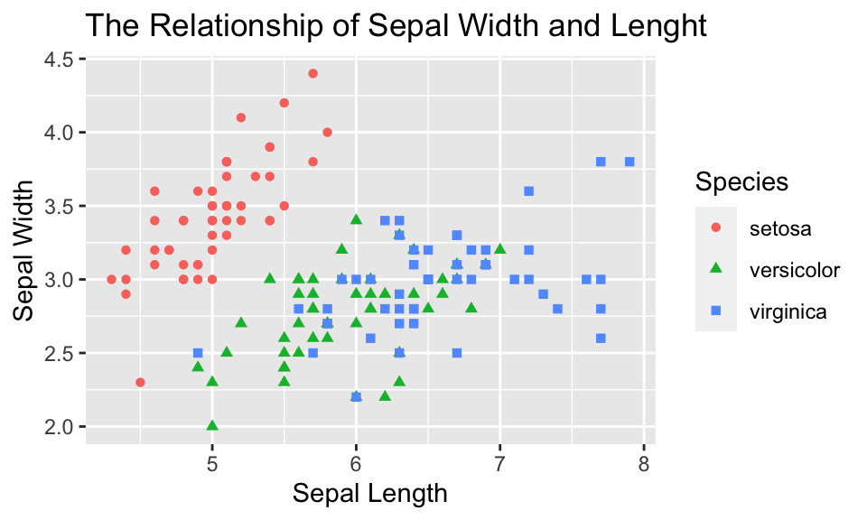

```r
plot +
  labs(x='Sepal Length',
       y='Sepal Width',
       title='The Relationship of Sepal Width and Lenght')
```

We could also add a regression line:

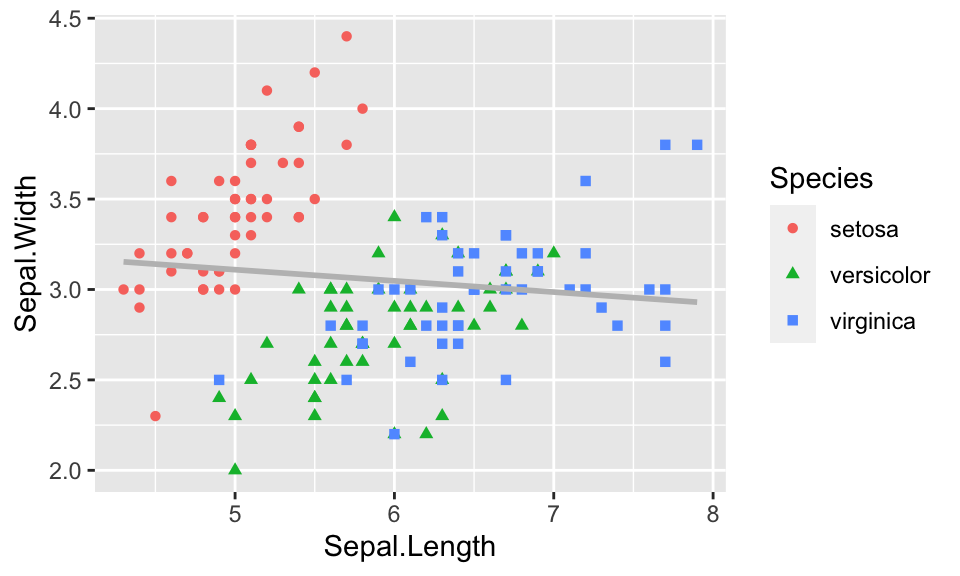

```r
plot +
  geom_smooth(method = 'lm', se = F,color='gray')
```

Maybe it would be better to have each species in a separate graph:

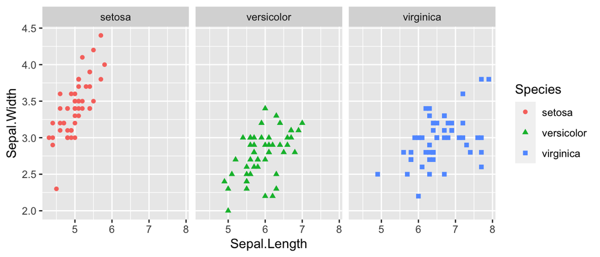

```r
plot +
  facet_wrap(~Species)
```

We are not confined to points. Here is a histogram of sepal length.

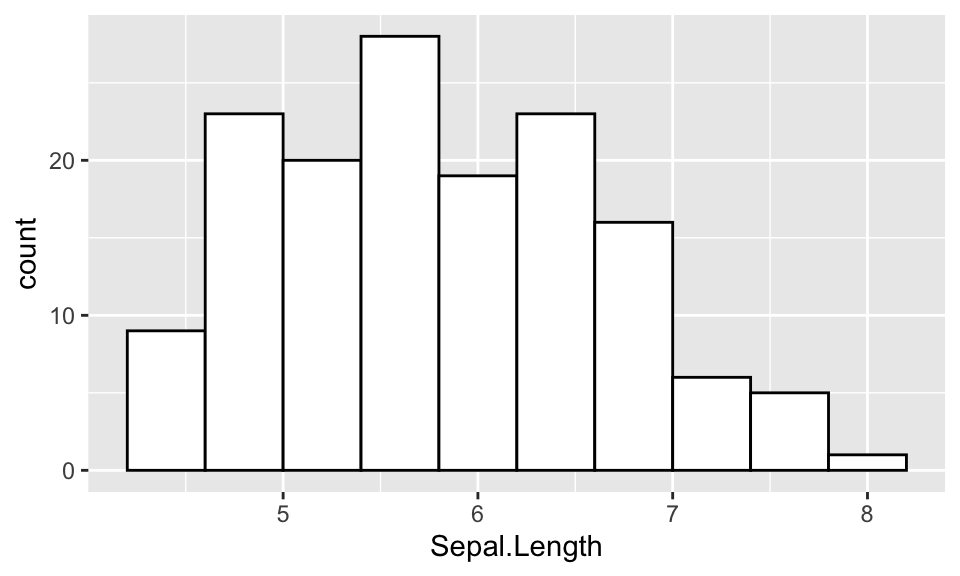

```r
ggplot(iris) +
  geom_histogram(mapping=aes(x=Sepal.Length),
                 bins = 10,color='black',fill='white')
```

There are many different geometries you can use:

- Lines: `geom_line`
- Boxplots: `geom_boxplot`
- Densities: `geom_density`
- Maps: `geom_map`
- Error Bars: `geom_errorbar`
- Uncertainty Intervals: `geom_ribbon`

and many more.

You can customize almost every aspect of a plot: axes, labels, grid lines, legend, orientation, size, palettes. However, `ggplot2` also offers a set of themes that modify several aspects of a figure at once:

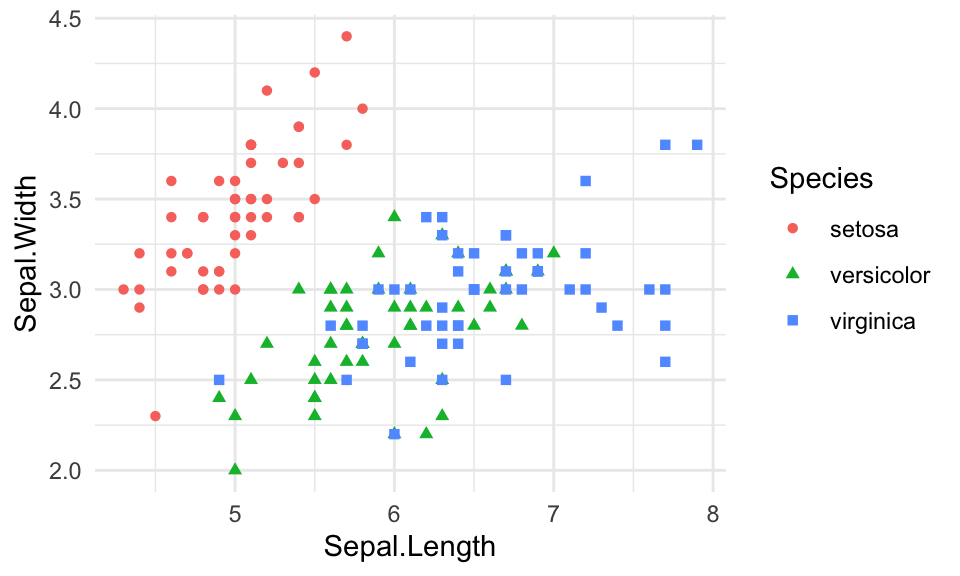

```r
plot +
  theme_minimal()
```

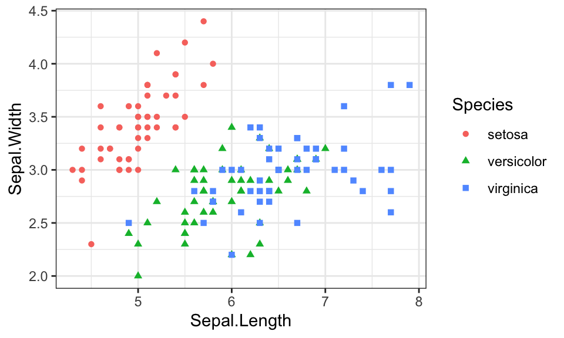

```r
plot +
  theme_bw()
```

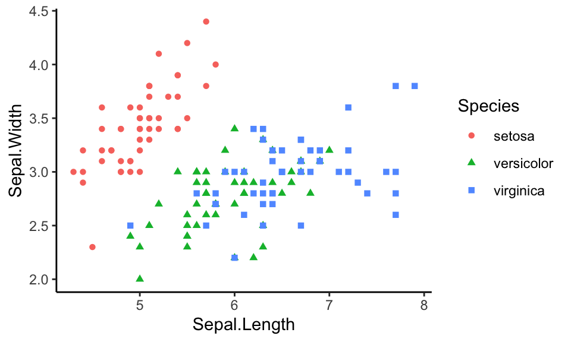

```r
plot +
  theme_classic()
```

and more are available through the `ggthemes` package.

*Exercise*

Using the `iris` dataset, create a new graph with a different box plot of `Sepal.Width` for each Species. Label the axes in an appropriate way. Use the theme you prefer.

```r
ggplot(data=iris) +
  geom_*(mapping=aes(x=,y=)) +
  labs() +
  theme_*()
```

*Solution*

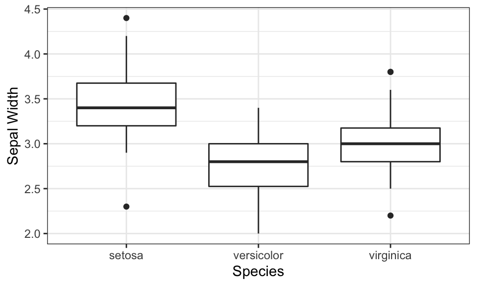

```r
ggplot(data=iris) +
  geom_boxplot(mapping=aes(x=Species,y=Sepal.Width)) +
  labs(y='Sepal Width') +
  theme_bw()
```

### Communicating Your Results with RMarkdown

You might have noticed how this presentation combines formatted text, R code and plots. This presentation uses RMarkdown, a system integrated in RStudio that lets you write code through a notebook interface and create reproducible documents.

If you clone the repository where I uploaded this presentation’s material you’ll be able to recreate this document with a simple click of the “Knit” button in RStudio.

You have many different output types you can choose from: html, markdown, doc, pdf (through LaTex), and others.

You can learn more about RMarkdown functionalities [here](https://rmarkdown.rstudio.com/lesson-1.html).